# Zuwachs

Johannes Osewold

2023-05-23

Zunächst folgen hier zwei Graphen die ich bereits vor einer Weile gebastelt habe und die nur dazu dienten einen ersten Einblick in die Eschen und Zuwachssituation des Göttingen und Lauenburg Datasets zu bekommen.

Der Erste Graph vergleicht die Anzahl der Eschen zwischen 2021 (blau) und 2022 (rot). Der zweite Graph macht das gleich mit den durchschnittlichen Höhen pro Plot.

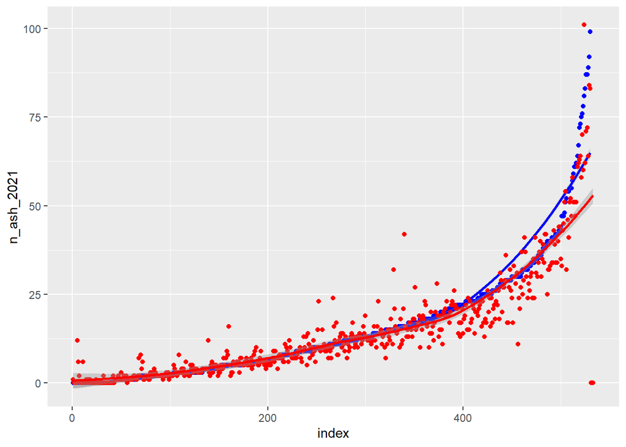

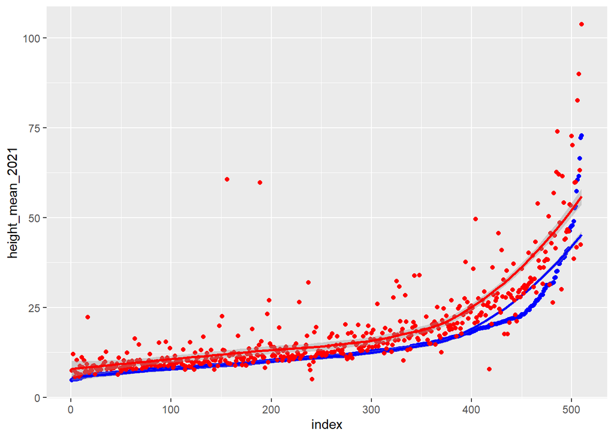

Um den Zuwachs tatsächlich pro Plot einzuschätzen hilft die folgenden Graphik. In Rot ist sind wieder die Bäume 2022 eingezeichnet und in blau die 2021er. Sie sind nach Größe sortiert und die 2022 (meistens weniger) wurden am rechten Rand in den Graphen inkludiert. In der zweiten Graphik wurden außerdem die einjährigen Sämlinge ausgeschlossen, wobei das natürlich nur für die Eschen geht. Für den Zuwachs wurden in diesen Graphen aber alle Baumarten verwendet. Das erschien sinnvoll um erstmal einen übergreifenden Zuwachs zu berechnen, der anschließend mit dem TSF verglichen werden kann.

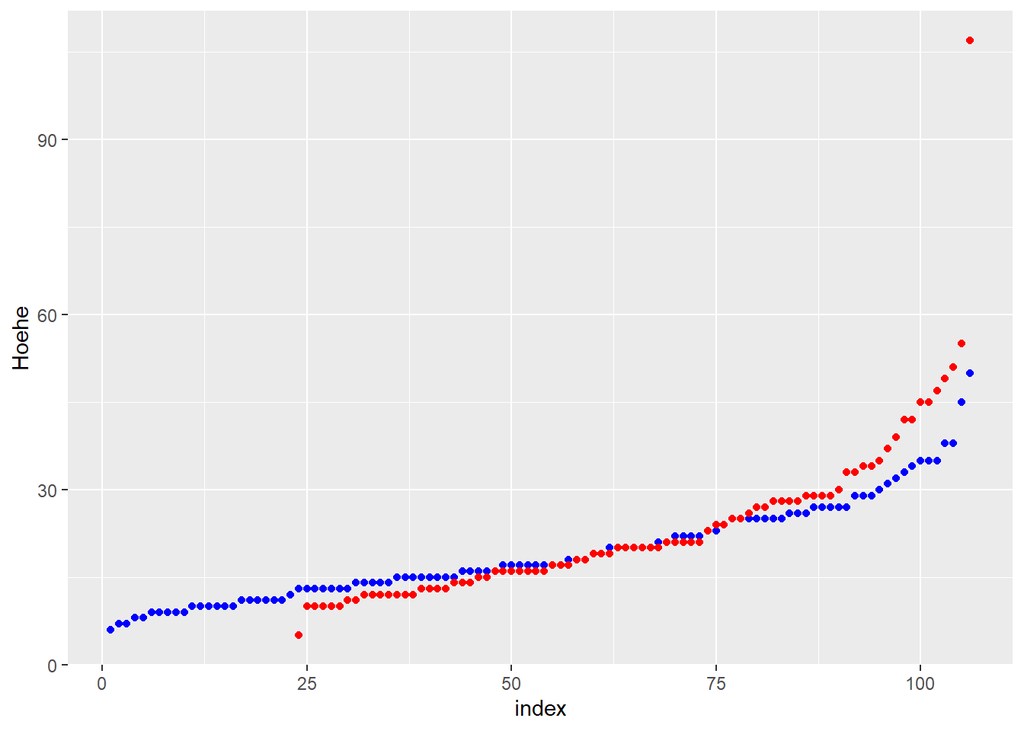

[figure not shown]

Man könnte nun die höchsten paar Prozent nehmen und nur die für den Zuwachs verwenden. Das wird dann aber ein Problem wenn Bäume mit rein genommen wurden, die letztes Jahr noch außerhalb lagen. Aber das kann man ja vielleicht noch filtern. Manuell dann vermutlich.

Am Ende habe ich nun die 30% höchsten Bäume verwendet und noch nicht manuell gefiltert sondern nur in der folgenden Darstellung nach Zuwachs größer 0 und n-trees größer 20 gefilter. Der Vollständigkeit halber gibt es noch eine zweite Darstellung ganz ohne filter.

Leider sieht das noch nicht besonders gut aus. Und fürs Gefühl dass das nicht alles kompletter Unsinn ist gibt es noch einen Graphen mit Zuwachs zu Baumhöhe. Das ist vernünftig korreliert.

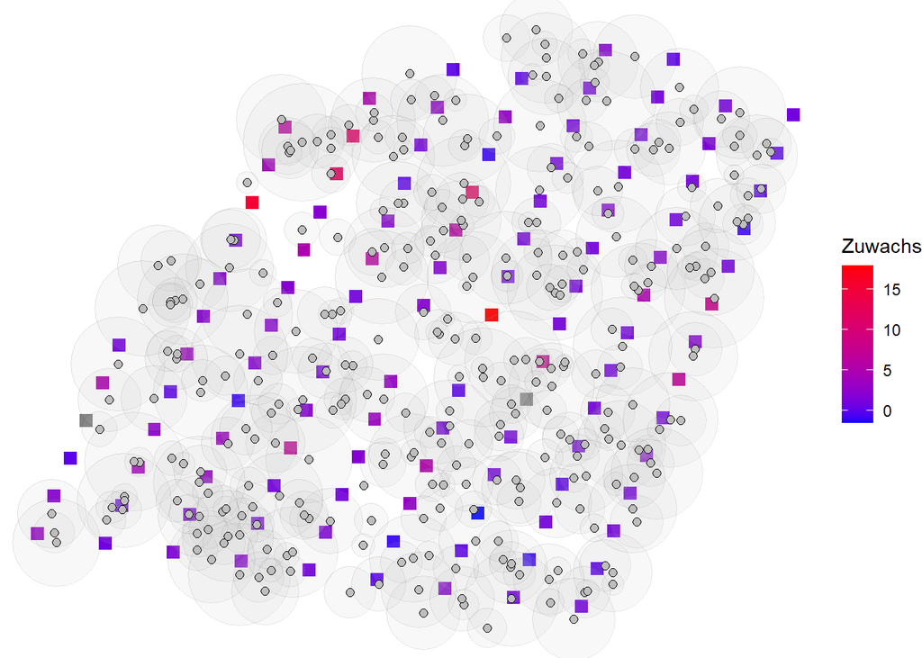

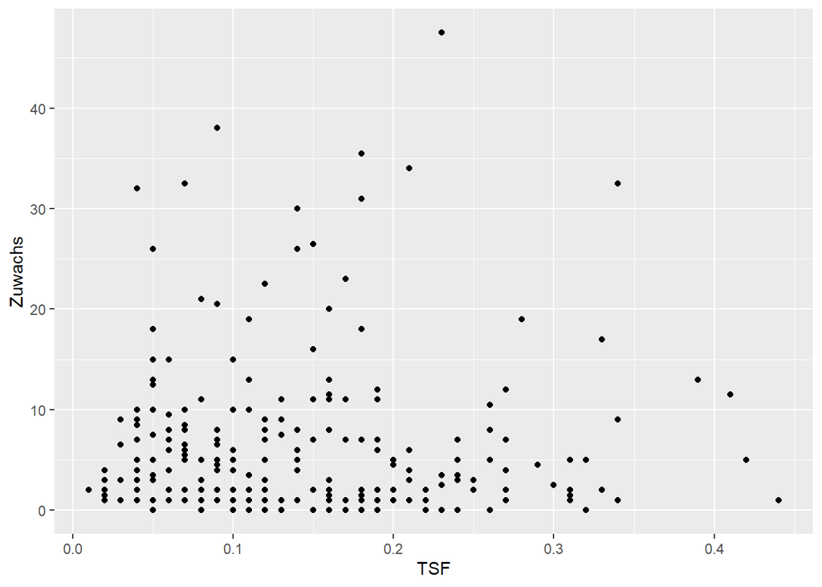

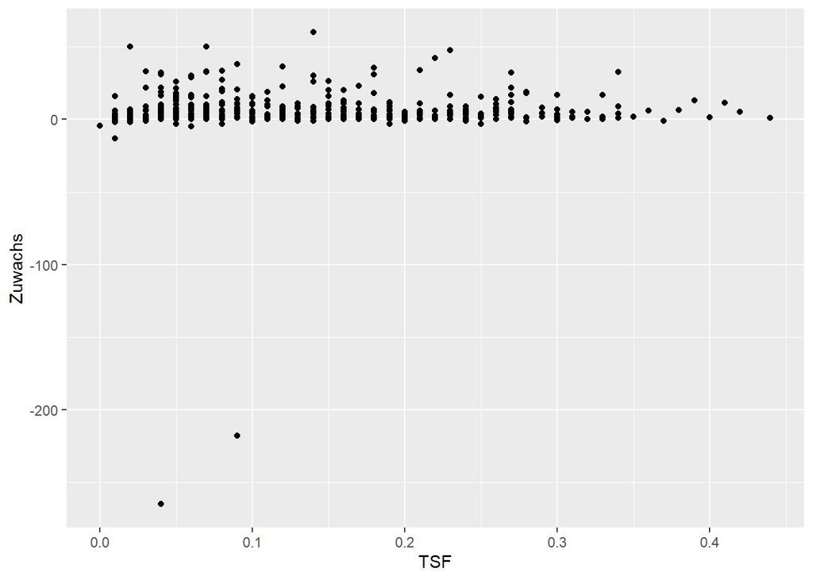

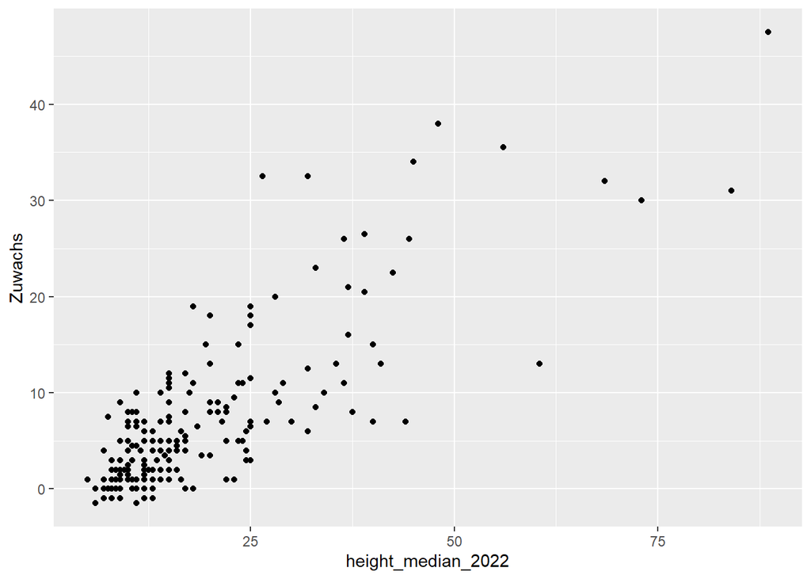

Das legt ja nun den Verdacht nahe das, der TSF Unsinn ist, immerhin passt der Zuwachs ja wunderbar zu der bestehenden Baumhöhe. Das lässt sich aber ziemlich gut mit einer Verteilung des TSF in Lauenburg widerlegen.

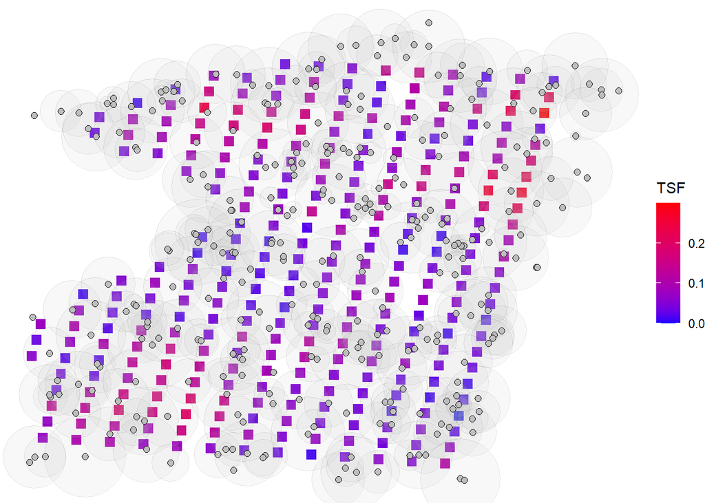

Also hat es offenbar irgendwas mit dem Alter der Löcher zu tun. Es scheint so als wären die nicht gleichzeitig aufgelichtet worden. Gerade am Weg ist das Licht sehr wahrscheinlich schon länger da.

Man könnte jetzt noch gucken ob sich der Zuwachs zwischen der Hauptkonkurrenzbaumart Bergahorn irgendwie in Abhängigkeit vom Licht verändert, dafür wurde hier einfach mal der Zuwachs von BAh vom Esch zuwachs abgezogen und das auf x = TSF geplottet. Plus ein paar filter natürlich. Erstmal in Lauenburg verteilt, und dann noch als normaler Plot.

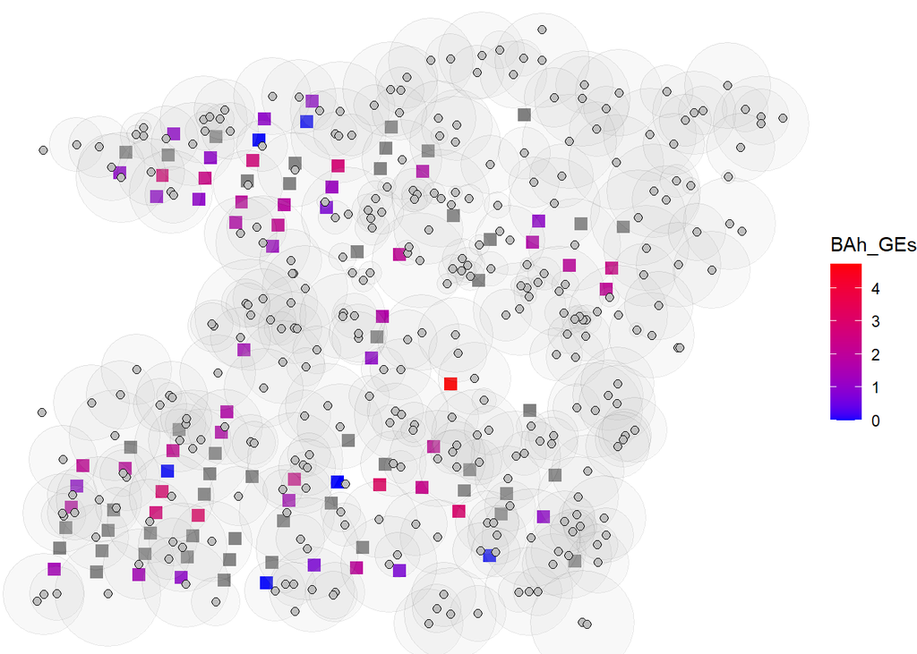

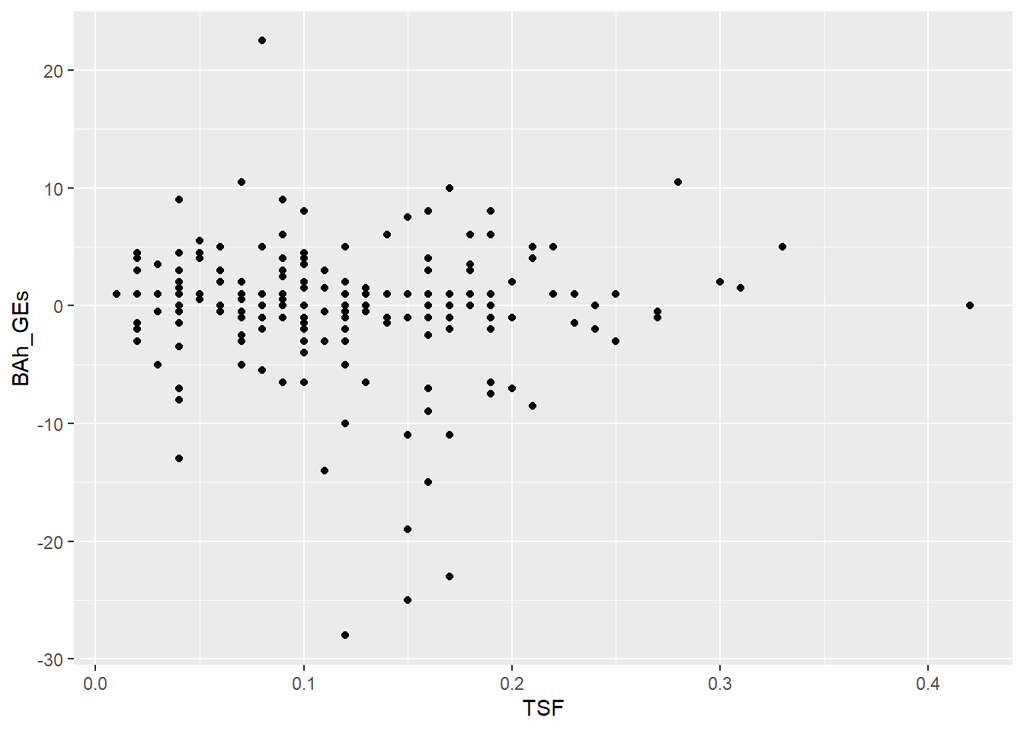

Nun war aber ja die Hauptfrage eigentlich Zuwachs ~ ETS, und alles vorherige in diesem Dokument diente eher dazu den Zuwachs zu verifizieren, also zu belegen, dass der Weg wie ich den berechne halbwegs Sinn ergibt.